# GAMs

Ihsan Khaliq

2023-04-03

Load libraries

```r
library("readxl")
library("tidyverse")
library("ggeffects")
library("here")
library("lubridate")
library("ggpubr")
library("mgcv")
library("kableExtra")
library("DHARMa")
library("gratia")
library("mgcViz")
library("patchwork")
library("broom")

# theme_set(theme_pubr(base_family = "Arial", base_size = 15))
```

### Import disease data

```r
dt_seasonal <-
  read_excel("data/fungicides_data.xlsx", sheet = 2) %>%
  mutate(across(where(is.character), as.factor)) %>%
  mutate(trial_duration = as.integer(trial_duration)) %>%
  select(
    assessment_date,
    assessment_num,
    year,
    avg_severity_plot,
    avg_severity_treatment,
    diseased_plants_plot,
    perc_incidence_plot,
    perc_incidence_treatment,
    trial_duration
  ) %>%
  dplyr::mutate(severity = avg_severity_treatment / 100) %>%
  dplyr::mutate(disease_severity = avg_severity_plot / 100)
```

### Import weather data

```r
# Calculations over assessment periods
weather_dt_seasonal <-
  read_excel("data/fungicides_data_dailyweather_suffruticosaonly.xlsx",
             sheet = 1) %>%
  dplyr::mutate(assessment_num = as.factor(assessment_num)) %>%
  mutate_if(is.character, as.factor) %>%
  group_by(year) %>%
  summarise(
    min_rh = round(mean(min_rh), 1),
    max_rh = round(mean(max_rh), 1),
    mean_rh = round(mean(mean_rh), 1),
    min_temp = round(mean(min_temp), 1),
    max_temp = round(mean(max_temp), 1),
    mean_temp = round(mean(mean_temp), 1),
    diurnal_temp = round(max_temp - min_temp, 1),
    min_ws = round(mean(min_ws), 1),
    max_ws = round(mean(max_ws), 1),
    mean_ws = round(mean(mean_ws), 1),
    mean_rain = round(mean(precipitation), 1),
    total_rain = round(sum(precipitation), 1),
    total_days = length(unique(date)),
    precip_days = sum(precipitation == "0"),
    # rainless days
    rainy_days = total_days - precip_days,
    perc_rainy_days = rainy_days / total_days * 100,
    avg_daily_rain = round(total_rain / rainy_days, 1),
    rain_everyday = total_rain / total_days
  )

# Filter rainy days to calculate wind speed and temp during rainy days.

weather_dat_rain <-
  read_excel("data/fungicides_data_dailyweather_suffruticosaonly.xlsx",
             sheet = 1) %>%
  select(
    !c(
      assessment_num_orig,
      assessment_num,
      cultivar,
      mean_rh,
      min_rh,
      max_rh,
      mean,
      min,
      max
    )
  ) %>%
  mutate_if(is.character, as.factor) %>%
  filter(precipitation > 0) %>%
  group_by(year) %>%
  summarise(min_temp_rain = round(mean(min_temp), 1),
            max_ws_rain = round(mean(max_ws), 1))

# Filter rainless days to calculate RH during rainless days.

weather_dat_no_rain <-
  read_excel("data/fungicides_data_dailyweather_suffruticosaonly.xlsx",
             sheet = 1) %>%
  select(mean_rh, min_rh, max_rh, precipitation, year) %>%
  mutate_if(is.character, as.factor) %>%
  filter(precipitation == 0) %>%
  group_by(year) %>%
  summarise(max_rh_dry = round(mean(max_rh), 1),
            mean_rh_dry = round(mean(mean_rh), 1))

# Combine data weather data during rainy and rain less periods

combined <-
  left_join(weather_dat_rain, weather_dat_no_rain, by = "year")


# Sort weather data for RH > 65 & below 65%
weather_dat_exposure <-
  read_excel("data/fungicides_data_dailyweather_suffruticosaonly.xlsx",
             sheet = 1) %>%
  select(min_rh, year) %>%
  mutate_if(is.character, as.factor) %>%
  dplyr::group_by(year) %>%
  dplyr::mutate(humidity_catog = as.factor(case_when(min_rh < 65 ~ "RH1",
                                                     min_rh >= 65 ~ "RH2")))

# Count each RH category
weather_dat_exposure_rh <- weather_dat_exposure %>%
  group_by(year, humidity_catog) %>%
  summarize(humidity_count = n()) %>%
  pivot_wider(names_from = humidity_catog, values_from = humidity_count)
# Combine with weather data
combined_rh <-
  left_join(combined,  weather_dat_exposure_rh, by = "year")

# Combine data weather data during rainy and rain less periods with weather recorded over entire duration
weather_dat_seasonal <-
  left_join(weather_dt_seasonal, combined_rh, by = "year")
```

### Combine data

```r
dat_seasonal <-
  left_join(dt_seasonal, weather_dat_seasonal, by = "year") %>%
  select(!c(assessment_date,  assessment_num, trial_duration)) %>%
  select(year, everything())
```

### Set seed for reproducibility

```r
set.seed(42)
```

# Main effect of weather variables

## M1 (min_rh, min_temp, max_ws, mean_rain_per_rainy_day)

Using mean rain per rainy day, and mean values for daily minimum relative humidity, daily minimum temperatures, and daily maximum wind speed over the trial duration.

```r
m1 <- gam(disease_severity ~  s(min_rh, k = 10) + s(min_temp, k = 10) + s(max_ws, k =7) + s(avg_daily_rain, k = 9) + s(total_days, k=9), family = betar(),  method = "REML", data = dat_seasonal)

summary(m1)
```

```
##
## Family: Beta regression(8.814)
## Link function: logit
##
## Formula:
## disease_severity ~ s(min_rh, k = 10) + s(min_temp, k = 10) +
##     s(max_ws, k = 7) + s(avg_daily_rain, k = 9) + s(total_days,
##     k = 9)
##
## Parametric coefficients:
##             Estimate Std. Error z value Pr(>|z|)
## (Intercept) -0.03208    0.12461  -0.257    0.797
##
## Approximate significance of smooth terms:
##                     edf Ref.df Chi.sq p-value
## s(min_rh)         1.000  1.000 28.231 < 2e-16 ***
## s(min_temp)       1.645  1.837 33.003 6.3e-05 ***
## s(max_ws)         1.000  1.000  0.282  0.5954
## s(avg_daily_rain) 4.076  4.481 36.052 5.8e-07 ***
## s(total_days)     1.000  1.000  2.988  0.0839 .
## ---
## Signif. codes:  0 '***' 0.001 '**' 0.01 '*' 0.05 '.' 0.1 ' ' 1
##
## R-sq.(adj) =   0.87   Deviance explained = 92.8%
## -REML = -35.104  Scale est. = 1         n = 41
```

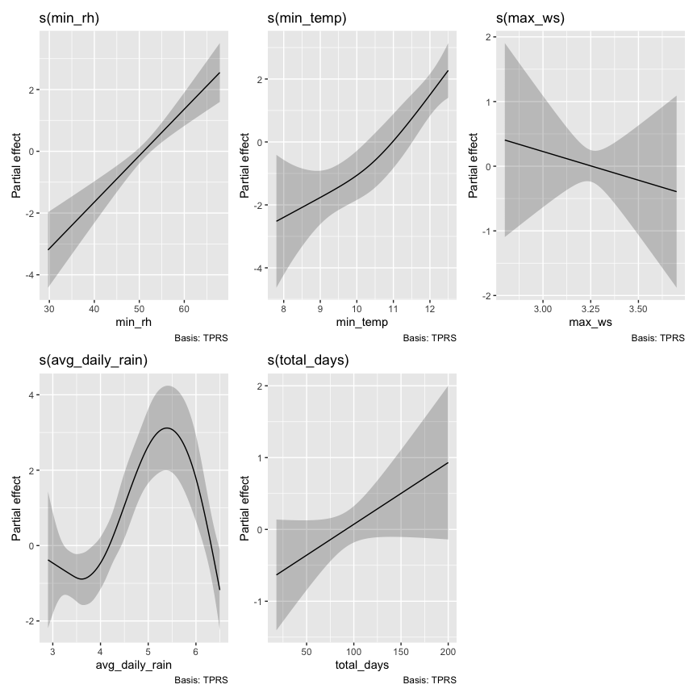

```r
draw(m1, resid_col = TRUE, rug = FALSE, caption = NULL)
```

## M2 (min_rh, min_temp_rain, max_ws_rain, mean_rain_per_rainy_day)

Based on correlation analysis, daily minimum temperature and daily maximum wind speed during rainy days has a higher correlation with disease, so use these variables instead of mean values for daily minimum temperatures and daily maximum wind speed over the trial duration.

```r
m2 <- gam(disease_severity ~  s(min_rh, k = 9) + s(min_temp_rain, k = 9) + s(max_ws_rain, k =7) + s(avg_daily_rain, k = 9) + s(total_days, k=9), family = betar(),  method = "REML", data = dat_seasonal)

summary(m2)
```

```
##
## Family: Beta regression(8.716)
## Link function: logit
##
## Formula:
## disease_severity ~ s(min_rh, k = 9) + s(min_temp_rain, k = 9) +
##     s(max_ws_rain, k = 7) + s(avg_daily_rain, k = 9) + s(total_days,
##     k = 9)
##
## Parametric coefficients:
##             Estimate Std. Error z value Pr(>|z|)
## (Intercept) -0.02834    0.12484  -0.227     0.82
##
## Approximate significance of smooth terms:
##                     edf Ref.df Chi.sq p-value
## s(min_rh)         2.185  2.331 42.764 < 2e-16 ***
## s(min_temp_rain)  1.000  1.000 29.986 < 2e-16 ***
## s(max_ws_rain)    1.000  1.000  0.002   0.964
## s(avg_daily_rain) 3.840  4.301 57.295 1.2e-07 ***
## s(total_days)     1.000  1.000  1.001   0.317
## ---
## Signif. codes:  0 '***' 0.001 '**' 0.01 '*' 0.05 '.' 0.1 ' ' 1
##
## R-sq.(adj) =  0.868   Deviance explained = 92.8%
## -REML = -35.364  Scale est. = 1         n = 41
```

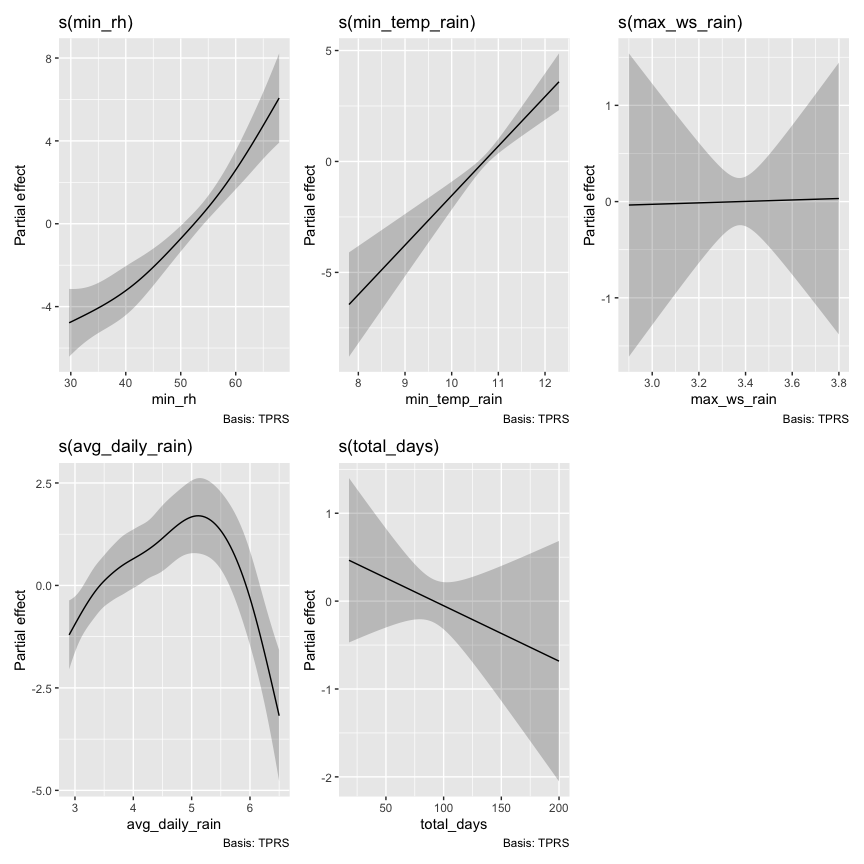

```r
draw(m2, resid_col = TRUE, rug = FALSE, caption = NULL)
```

Same output as `m1`.

## M3 (max_rh_dry, min_temp_rain, max_ws_rain, mean_rain_per_rainy_day)

Add daily maximum relative humidity during dry days, which has the highest correlation with the disease.

```r
m3 <- gam(disease_severity ~  s(max_rh_dry, k = 10) + s(min_temp_rain, k = 9) + s(max_ws_rain, k =7) + s(avg_daily_rain, k = 9) + s(total_days, k=10), family = betar(),  method = "REML", data = dat_seasonal)

summary(m3)
```

```
##
## Family: Beta regression(8.706)
## Link function: logit
##
## Formula:
## disease_severity ~ s(max_rh_dry, k = 10) + s(min_temp_rain, k = 9) +
##     s(max_ws_rain, k = 7) + s(avg_daily_rain, k = 9) + s(total_days,
##     k = 10)
##
## Parametric coefficients:
##             Estimate Std. Error z value Pr(>|z|)
## (Intercept)   -0.032      0.125  -0.256    0.798
##
## Approximate significance of smooth terms:
##                     edf Ref.df Chi.sq p-value
## s(max_rh_dry)     3.401  3.510  2.174 0.57566
## s(min_temp_rain)  1.000  1.000  0.085 0.77060
## s(max_ws_rain)    1.000  1.000  0.360 0.54825
## s(avg_daily_rain) 2.676  2.768 15.768 0.00483 **
## s(total_days)     1.669  1.701  1.907 0.22396
## ---
## Signif. codes:  0 '***' 0.001 '**' 0.01 '*' 0.05 '.' 0.1 ' ' 1
##
## R-sq.(adj) =  0.866   Deviance explained = 92.9%
## -REML = -31.287  Scale est. = 1         n = 41
```

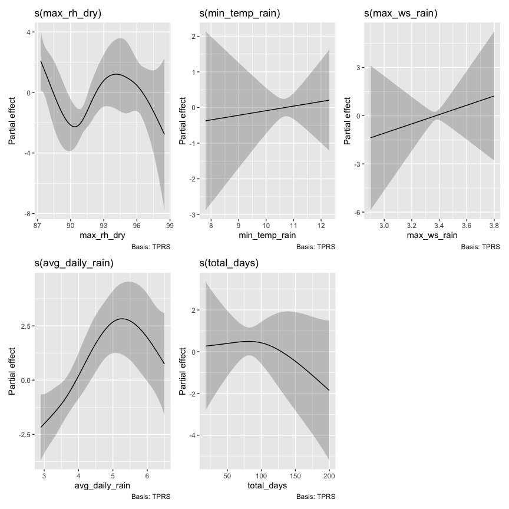

```r
draw(m3, resid_col = TRUE, rug = FALSE, caption = NULL)
```

Only rainfall has a significant on disease severity.

## M4 (RH2, min_temp_rain, max_ws_rain, mean_rain_per_rainy_day)

Use the number of days with relative humidity over 65% as a predictor, which has the second highest correlation with the disease after after maximum relative humidity during dry conditions.

```r
m4 <- gam(disease_severity ~  s(RH2, k = 9) + s(min_temp_rain, k = 9) + s(max_ws_rain, k =7) + s(avg_daily_rain, k = 9) + s(total_days, k=9), family = betar(),  method = "REML", data = dat_seasonal)

summary(m4)
```

```
##
## Family: Beta regression(8.816)
## Link function: logit
##
## Formula:
## disease_severity ~ s(RH2, k = 9) + s(min_temp_rain, k = 9) +
##     s(max_ws_rain, k = 7) + s(avg_daily_rain, k = 9) + s(total_days,
##     k = 9)
##
## Parametric coefficients:
##             Estimate Std. Error z value Pr(>|z|)
## (Intercept) -0.02355    0.12418   -0.19     0.85
##
## Approximate significance of smooth terms:
##                     edf Ref.df Chi.sq  p-value
## s(RH2)            1.000  1.000 10.146 0.001446 **
## s(min_temp_rain)  1.000  1.000 11.370 0.000746 ***
## s(max_ws_rain)    1.000  1.000  0.122 0.727412
## s(avg_daily_rain) 2.666  2.860 13.894 0.008116 **
## s(total_days)     3.819  4.029 19.063 0.000422 ***
## ---
## Signif. codes:  0 '***' 0.001 '**' 0.01 '*' 0.05 '.' 0.1 ' ' 1
##
## R-sq.(adj) =  0.865   Deviance explained = 92.8%
## -REML = -32.793  Scale est. = 1         n = 41
```

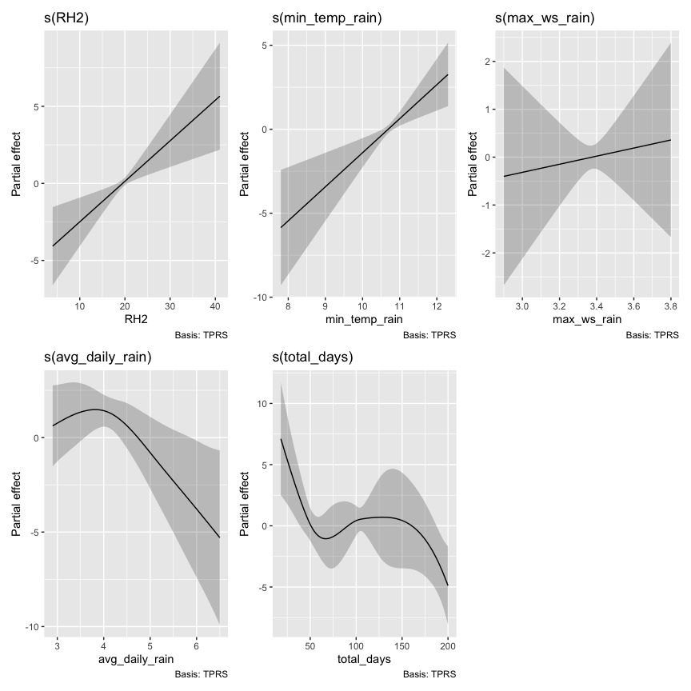

```r
draw(m4, resid_col = TRUE, rug = FALSE, caption = NULL)
```

Same output as `m1` and `m2`, but trial duration has a significant effect. This means trial duration is important when number of days with relative humidity over 65% is used as a predictor, so this predictor is not normalising the data for varying trial period.

Use mean RH as a predictor, which has the third highest correlation with the disease after after maximum relative humidity during dry conditions.

```r
m5 <- gam(disease_severity ~  s(mean_rh, k = 9) + s(min_temp, k = 9) + s(max_ws, k =7) + s(avg_daily_rain, k = 10) + s(total_days, k=9), family = betar(),  method = "REML", data = dat_seasonal)

summary(m5)
```

```
##
## Family: Beta regression(8.8)
## Link function: logit
##
## Formula:
## disease_severity ~ s(mean_rh, k = 9) + s(min_temp, k = 9) + s(max_ws,
##     k = 7) + s(avg_daily_rain, k = 10) + s(total_days, k = 9)
##
## Parametric coefficients:
##             Estimate Std. Error z value Pr(>|z|)
## (Intercept) -0.03721    0.12466  -0.298    0.765
##
## Approximate significance of smooth terms:
##                     edf Ref.df Chi.sq  p-value
## s(mean_rh)        1.000  1.000  6.249   0.0124 *
## s(min_temp)       1.611  1.686 12.595   0.0208 *
## s(max_ws)         1.000  1.000  6.530   0.0106 *
## s(avg_daily_rain) 2.449  2.556 12.276   0.0614 .
## s(total_days)     3.367  3.616 23.143 8.17e-05 ***
## ---
## Signif. codes:  0 '***' 0.001 '**' 0.01 '*' 0.05 '.' 0.1 ' ' 1
##
## R-sq.(adj) =  0.865   Deviance explained = 92.9%
## -REML = -33.276  Scale est. = 1         n = 41
```

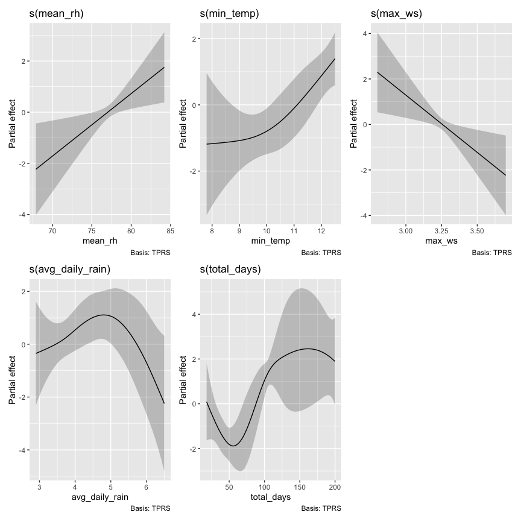

```r
draw(m5, resid_col = TRUE, rug = FALSE, caption = NULL)
```

## Compare models and choose the best fit model

### AIC, BIC

```r
models <- list(
  mod1 = m1,
  mod2 = m2,
  mod3 = m3,
  mod4 = m4,
  mod5 = m5
)
map_df(models, glance, .id = "model") %>%
  arrange(AIC)
```

```
## # A tibble: 5 × 8
##   model    df logLik   AIC   BIC deviance df.residual  nobs
##   <chr> <dbl>  <dbl> <dbl> <dbl>    <dbl>       <dbl> <int>
## 1 mod1   9.72   48.6 -74.6 -55.2     29.9        31.3    41
## 2 mod5  10.4    48.8 -74.0 -53.6     29.4        30.6    41
## 3 mod2  10.0    48.6 -73.9 -54.0     29.5        31.0    41
## 4 mod3  10.7    48.8 -73.7 -53.2     29.0        30.3    41
## 5 mod4  10.5    48.7 -73.6 -53.2     29.8        30.5    41
```

The `m1` model has lowest AIC and BIC values

### R-squared values

```r
enframe(
  c(
    mod1 = summary(m1)$r.sq,
    mod2 = summary(m2)$r.sq,
    mod3 = summary(m3)$r.sq,
    mod4 = summary(m4)$r.sq,
    mod5 = summary(m5)$r.sq
  )
) %>%
  arrange(desc(value))
```

```
## # A tibble: 5 × 2
##   name  value
##   <chr> <dbl>
## 1 mod1  0.870
## 2 mod2  0.868
## 3 mod3  0.866
## 4 mod5  0.865
## 5 mod4  0.865
```

The `m1` model has the highest R-squared values.

## Best fit model `m` diagnostics

### Check if the best fit model `m1` predictions are reliable

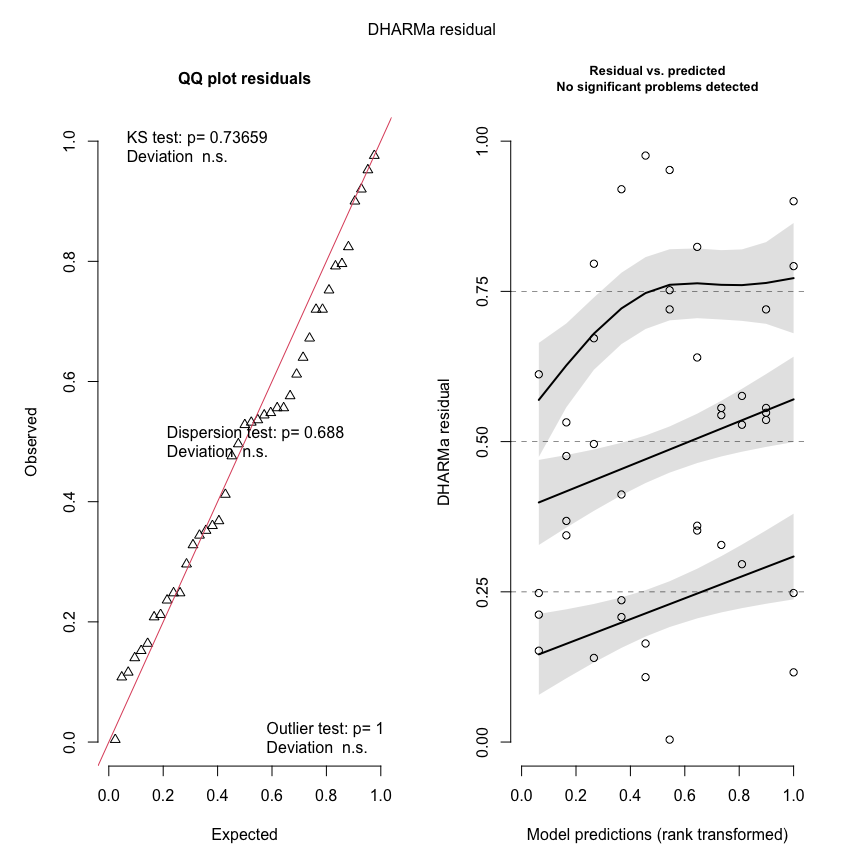

```
## Object of Class DHARMa with simulated residuals based on 250 simulations with refit = FALSE . See ?DHARMa::simulateResiduals for help.
##
## Scaled residual values: 0.108 0.976 0.164 0.528 0.296 0.576 0.14 0.672 0.496 0.796 0.352 0.36 0.824 0.64 0.544 0.556 0.328 0.004 0.752 0.952 ...
```

```r
simulateResiduals(m1, plot = T, quantreg = T)
```

Yes, predictions are reliable and truly represent the data.

### Diagnostics plots

```
##
## Method: REML   Optimizer: outer newton
## full convergence after 12 iterations.
## Gradient range [-7.458491e-06,4.702566e-06]
## (score -35.10438 & scale 1).
## Hessian positive definite, eigenvalue range [7.607552e-08,16.71132].
## Model rank =  41 / 41
##
## Basis dimension (k) checking results. Low p-value (k-index<1) may
## indicate that k is too low, especially if edf is close to k'.
##
##                     k'  edf k-index p-value
## s(min_rh)         9.00 1.00    1.14    0.80
## s(min_temp)       9.00 1.65    1.18    0.86
## s(max_ws)         6.00 1.00    1.14    0.81
## s(avg_daily_rain) 8.00 4.08    1.20    0.82
## s(total_days)     8.00 1.00    1.10    0.74
```

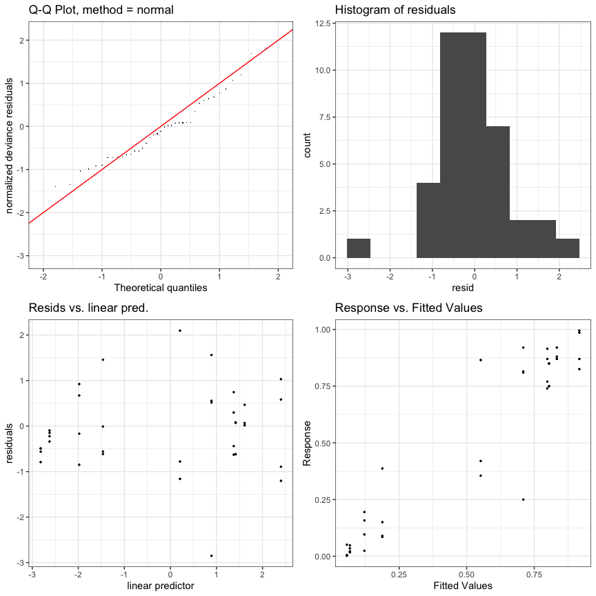

```r
m1_vis <- getViz(m1)
check(
  m1_vis,
  a.qq = list(method = "tnorm",
              a.cipoly = list(fill = "light blue")),
  a.respoi = list(size = 0.5),
  a.hist = list(bins = 10)
)
```

The `k` values are greater than `edf` and p-values are not significant. More data will further increase the fit.

### Check autocorrelation

```r
performance::check_autocorrelation(m1)
```

```
## OK: Residuals appear to be independent and not autocorrelated (p = 0.496).
```

# Interaction effect of weather variables

```r
dat_season <- dat_seasonal %>%
  rename(rain_per_rainy_day = avg_daily_rain,
         daily_minimum_temperature = min_temp)

mod1 <-
  gam(
    disease_severity ~  te(min_rh,  daily_minimum_temperature, k = 4) +  te(max_ws, rain_per_rainy_day, k = 5),
    family = betar(),
    method = "REML",
    data = dat_season
  )

summary(mod1)
```

```
##
## Family: Beta regression(8.84)
## Link function: logit
##
## Formula:
## disease_severity ~ te(min_rh, daily_minimum_temperature, k = 4) +
##     te(max_ws, rain_per_rainy_day, k = 5)
##
## Parametric coefficients:
##             Estimate Std. Error z value Pr(>|z|)
## (Intercept) -0.03709    0.12465  -0.298    0.766
##
## Approximate significance of smooth terms:
##                                        edf Ref.df Chi.sq p-value
## te(min_rh,daily_minimum_temperature) 3.000   3.00  39.62  <2e-16 ***
## te(max_ws,rain_per_rainy_day)        6.608   6.93  78.30  <2e-16 ***
## ---
## Signif. codes:  0 '***' 0.001 '**' 0.01 '*' 0.05 '.' 0.1 ' ' 1
##
## R-sq.(adj) =  0.867   Deviance explained = 92.9%
## -REML = -45.944  Scale est. = 1         n = 41
```

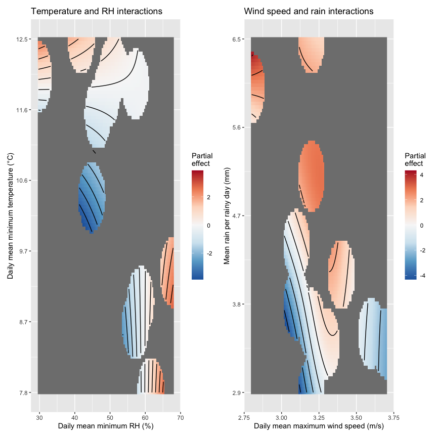

```r
p1 <- draw(mod1,  rug = FALSE,  select = smooths(mod1)[1]) +
  labs(
    x = "Daily mean minimum RH (%)",
    y = "Daily mean minimum temperature (°C)",
    title = "Temperature and RH interactions",
    caption = NULL
  ) +
  scale_y_continuous(breaks = seq(7.8, 12.5, length.out = 6),
                     labels = sprintf("%0.1f", seq(7.8, 12.5, length.out = 6)))

p2 <- draw(mod1,  rug = FALSE,  select = smooths(mod1)[2]) +
  labs(
    x = "Daily mean maximum wind speed (m/s)",
    y = "Mean rain per rainy day (mm)",
    title = "Wind speed and rain interactions",
    caption = NULL
  ) +
  scale_y_continuous(breaks = seq(2.9, 6.5, length.out = 5),
                     labels = sprintf("%0.1f", seq(2.9, 6.5, length.out = 5)))


fig_3 <- p1 + p2 + plot_layout(ncol = 2)
fig_3
```

### Check if the model predictions are reliable

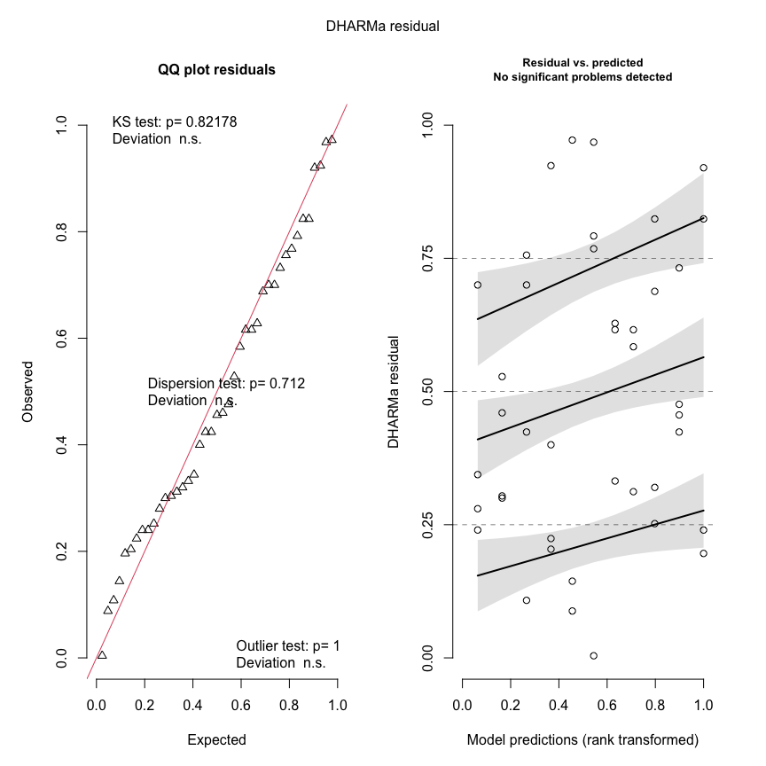

```
## Object of Class DHARMa with simulated residuals based on 250 simulations with refit = FALSE . See ?DHARMa::simulateResiduals for help.
##
## Scaled residual values: 0.088 0.972 0.144 0.584 0.312 0.616 0.108 0.7 0.424 0.756 0.252 0.32 0.824 0.688 0.616 0.628 0.332 0.004 0.792 0.968 ...
```

```r
simulateResiduals(mod1, plot = T, quantreg = T)
```

No problems detected.

### Diagnostics plots

```
##
## Method: REML   Optimizer: outer newton
## full convergence after 12 iterations.
## Gradient range [-7.458491e-06,4.702566e-06]
## (score -35.10438 & scale 1).
## Hessian positive definite, eigenvalue range [7.607552e-08,16.71132].
## Model rank =  41 / 41
##
## Basis dimension (k) checking results. Low p-value (k-index<1) may
## indicate that k is too low, especially if edf is close to k'.
##
##                     k'  edf k-index p-value
## s(min_rh)         9.00 1.00    1.14    0.80
## s(min_temp)       9.00 1.65    1.18    0.87
## s(max_ws)         6.00 1.00    1.14    0.78
## s(avg_daily_rain) 8.00 4.08    1.20    0.80
## s(total_days)     8.00 1.00    1.10    0.71
```

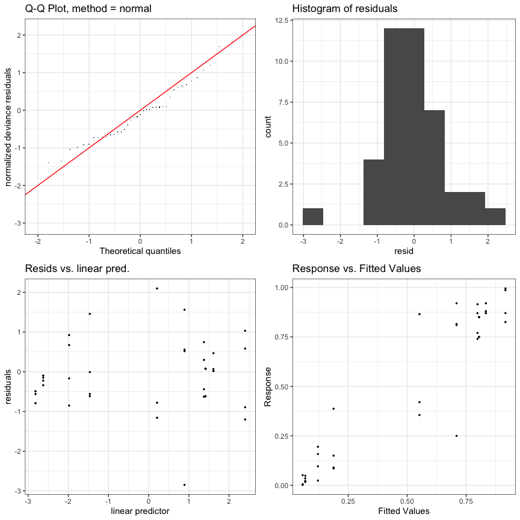

```r
mod1_vis <- getViz(m1)
check(
  mod1_vis,
  a.qq = list(method = "tnorm",
              a.cipoly = list(fill = "light blue")),
  a.respoi = list(size = 0.5),
  a.hist = list(bins = 10)
)
```

The `k` values are greater than `edf` and p-values are not significant. More data will further increase the fit.

### Check autocorrelation

```r
performance::check_autocorrelation(mod1)
```

```
## OK: Residuals appear to be independent and not autocorrelated (p = 0.616).
```

### Plot interaction effect of mean rain per rainy day and daily mean maximum

wind speed using `visreg` package

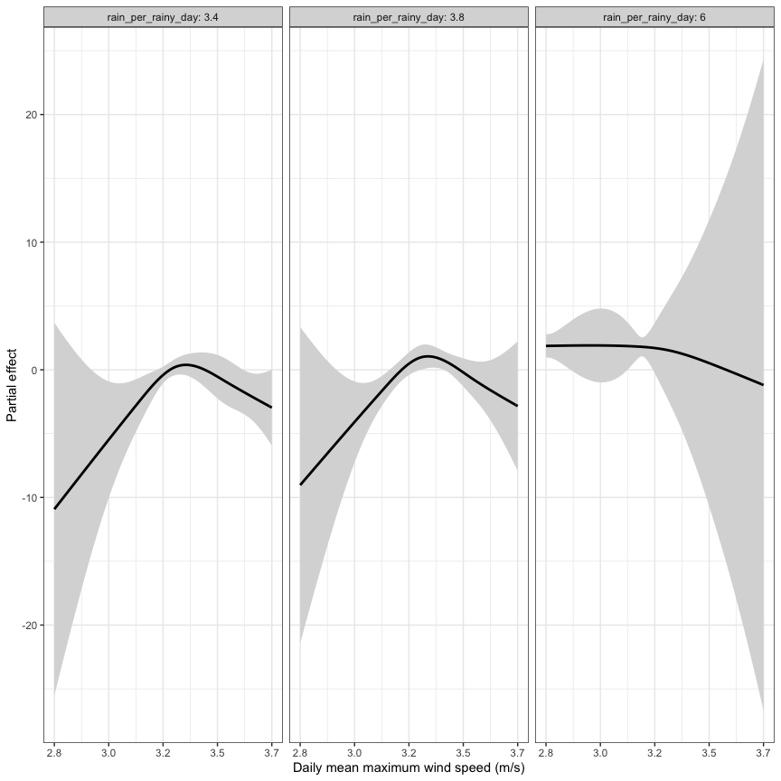

```r
fig_S2 <-
  visreg::visreg(
    mod1,
    "max_ws",
    by = "rain_per_rainy_day",
    gg = TRUE,
    rug = FALSE,
    partial = FALSE,
    line = list(col = "black")
  ) +  theme_bw() +
  labs(x = "Daily mean maximum wind speed (m/s)", y = "Partial effect") +
  scale_x_continuous(breaks = seq(2.8, 3.7, length.out = 5),
                     labels = sprintf("%0.1f", seq(2.8, 3.7, length.out = 5)))


fig_S2
```

### Plot interaction effect of mean mininum RH and mean mininum temp

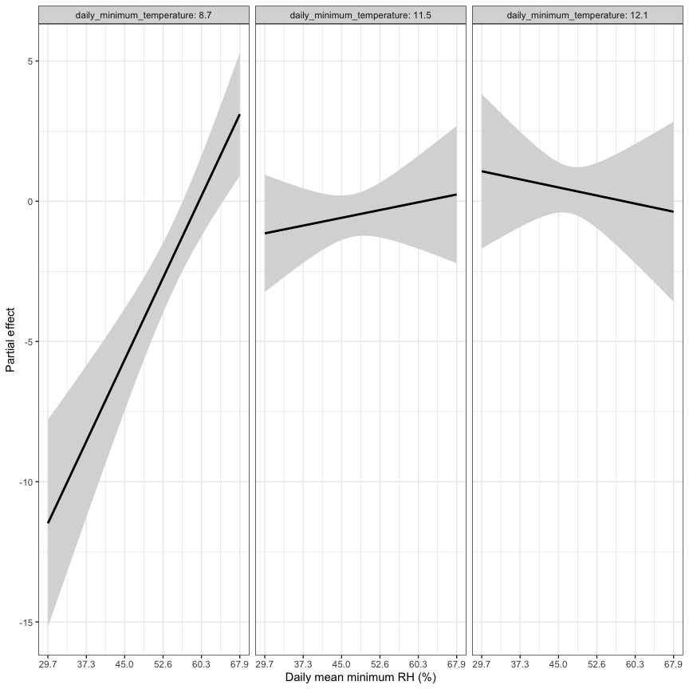

```r
fig_S3 <-
  visreg::visreg(
    mod1,
    "min_rh",
    by = "daily_minimum_temperature",
    gg = TRUE,
    rug = FALSE,
    partial = FALSE,
    line = list(col = "black")
  ) + theme_bw() +
  labs(x = "Daily mean minimum RH (%)",  y = "Partial effect") +
  scale_x_continuous(breaks = seq(29.7, 67.9, length.out = 6),
                     labels = sprintf("%0.1f", seq(29.7, 67.9, length.out = 6)))

fig_S3
```

The plot for interaction effect between RH and temperature suggests a negative interaction effect. This means that the effect of RH on disease_severity changes depending on the value of temperature. When temperature is low, an increase in RH is associated with a larger increase in disease_severity than when temperature is high.

The plot for the interaction effect between max_ws and avg_daily_rain suggests a negative interaction effect. This means that the effect of max_ws on disease_severity changes depending on the value of avg_daily_rain. When avg_daily_rain is low, an increase in max_ws is associated with a larger increase in disease_severity than when avg_daily_rain is high. No increase in disease severity is recorded, at 6 mm rain per rainy day, with increasing wind speed.